# FinalProject

**Predicting Premier League Match Outcomes: A Machine Learning Tutorial**

**Fall 2025 Data Science Final project**

**Harold Rathbun, Justin Pham, Pranav Vudumula, Marcus Young**

**Contributions:**

**Harold Rathbun:** Project Idea, Dataset Curation and Preprocessing, Data Exploration, Feature Engineering -> Computed rolling averages for previous 5 games in order to create more helpful predictors for the model to work with, in addition to data exploration, cleaning, etc.

**Justin Pham:** ML Algorithm Design/Development, ML Algorithm Training and Test Data Analysis -> Chose models, implemented training, testing, and analysis for the various models.

**Pranav Vudumula:** Visualization, Result Analysis, Conclusion, Final Tutorial Report Creation -> Expanded upon analysis, conclusions, and tutorialized the notebook.

**Marcus Young:** Result Analysis, Conclusion, Final Tutorial Report Creation, Hosting website -> Expanded conclusions, tutorialized notebook, perfomed final reading/reviewing/editing of notebook, and hosted final product.

## **Predicting Premier League Match Outcomes: A Machine Learning Tutorial**

## **Introduction:**

Accurate sports analytics represents a significant challenge in sports analytics with a multitude of factors needed to consider when determining the outcome. This project address this problem by determining which factors have the most signifcant contirbution in determining the end result for premier league matches and developing models based on these behaviors. With the English premier league being the most watched sports league in the world, a precise analysis is crucial for making informed decisions by clubs, analysts, and investors. Inaccurate modeling could result in poor team management, mis-investments, and signifcant financial losses.

The importance of this analysis extends beyond indvidual match days to long term strategy such as identifying if `Expected Goals (xg)` is a better predictor of future success than actual goals scored. Our investigation centers around answering these key questions: "Which historical statistics strongly correlate with scoring the most points?", "How effectively can machine learning models like Random Forest, Logistic Regression, and SVM predict match outcomes?", "How do we handle the statistical difficulty of predicting 'Draws'?". Through comprehensive analysis of the Premier League match data, we hope to develop a robust predictive model while providing insights into the predictive analysis.

```python
from google.colab import drive
drive.mount('/content/drive')
```

# 1. Imports and Initializations

```python
import pandas as pd
import numpy as np

from sklearn.ensemble import RandomForestClassifier
from sklearn.compose import ColumnTransformer
from sklearn.preprocessing import OneHotEncoder
from sklearn.pipeline import Pipeline
from sklearn.metrics import classification_report, confusion_matrix
from sklearn.inspection import permutation_importance

import matplotlib.pyplot as plt
import seaborn as sns
```

```python
import pandas as pd
file_path = '/content/drive/My Drive/CMSC320 Fall 2025/matches.csv'
df=pd.read_csv(file_path)
```

Below the first half of the code focuses on Data cleaning and optimization while the second half focuses on feature engineering.

# 2. Data Curation: Data Cleaning & Optimization

Link to dataset: https://www.kaggle.com/datasets/mhmdkardosha/premier-league-matches/data

NOTE: For a key of all the soccer statistic abbreviations used here, visit the link above. We have not pasted it here for the sake of readability, as it is quite long.

Real world sports data is often messy with a lot of noise making it rarely ready for immediate analysis especially if we want to use this data for a model.In the section below after loading matches.csv we then reduce noise, do some temporal formatting, and categroical optimization.

- Noise Reduction consists of dropping columns like `comp`, `notes`, and `match report`, which provide context for human readers but no vlaue for models.
- Temporal Formatting consists of converting the `date` column into the Python datetime format for chronological ordering.
- Categorical Optimization consists of converting object coumns like `venue` and `opponent` into categorical data to optimize memory usage and processing speed.

Another crucial step we need to handle is the season alignment. In the Premier league a season often times spans across 2 years. To fix this the correction logic we implement is by classifying anything played from August till the end of the year is grouped into the following years' season. This would make it so that anything played from August-December 2023 is part of the 2024 season, while anything played from January-July 2023 is still part of the current 2023 season. This ensures all matches belong to their proper season and the rolling averages we calculate are accurate.

# 3. Feature Engineering:

To predict the outcome of a match we cannot use statistics from the match itself or any future predictors. Hence we rely on past performance. Since the direct past performance wouldn't be a good indicator for what transpires in the coming match we create "Rolling Averages" for key metrics like `Goals for(gf)`, `Expected Gaols(xg)`, etc. By averaging these stats across the past 5 games we create a good metric for the teams current form and how they will most likley perform in their coming match. We then drop any original match specific columns to prevent data leakage.

```python
#Noise Reduction: dropping columns that aren't useful in our analysis
df.drop(columns=["Unnamed: 0", "comp", "round", "attendance", "match report", "notes"], inplace=True)

#Converting date column into proper python datetime format
df["date"] = pd.to_datetime(df["date"])

#Categorical Optimization, see above for explanation
df['venue'] = df['venue'].astype('category')
df['opponent'] = df['opponent'].astype('category')
df['team'] = df['team'].astype('category')
df['result'] = df['result'].astype('category')
df['day'] = df['date'].dt.day_name()

#Converting to proper python date and times formats
df["hour"] = df["time"].str.replace(":.+", "", regex=True).astype("int")
df["day_code"] = df["date"].dt.dayofweek

#Removing columns that are missing data, there are very few so we can simply remove them
df.dropna(inplace=True)

#Checking data for duplicates
print("number of duplicates", df.duplicated().sum())

df.dropna(inplace=True)
df.formation.value_counts()

#Changing formation into a more readable format
df.formation = df.formation.str.replace("◆", "")
df.formation = df.formation.str.replace("-0", "")
df.formation.value_counts()

#We need to fix some errors with season labeling, as explained above
print("seasons before", df["season"].unique())

#Sorting data by date and team to make sure the next steps work
df["date"] = pd.to_datetime(df["date"])
df = df.sort_values(["team", "date"]).reset_index(drop=True)

# Extract year and month
year = df["date"].dt.year
month = df["date"].dt.month

# Compute correct season: Aug–Dec belong to next year, Jan–Jul to current year
df["season"] = np.where(month >= 8, year + 1, year).astype(int)

#seasons are now correctly defined
print("seasons after",df["season"].unique())

# Ensure correct ordering
df = df.sort_values(["team", "season", "date"]).reset_index(drop=True)

df["goal_diff"] = df["gf"] - df["ga"] #making a goal differential column
df["points"] = df["result"].map({"W": 3, "D": 1, "L": 0}) #This is a useful mapping for record

# Stats we want rolling averages for
rolling_stats = ["gf", "ga", "xg", "xga", "sh", "sot", "poss", "goal_diff", "points"]

# Rolling window size: 5 games
window = 5

print("Rows before:", len(df)) #Printing out rows before we do data revision, so that we know exactly how much we are deleting

#This loop computes the rolling averages for the previous [window] games, we are using window=5.
for col in rolling_stats: #for each stat in the rolling_stats array
  df[f"{col}_roll{window}"] = (
      df.groupby(["team", "season"], observed=False)[col] #compute these by team
      .shift(1) # only can use past matches
      .rolling(window) # how many previous games we are averaging over, 5 in this case
      .mean() #average
      .reset_index(level=0, drop=True) #Maintaining indicies
  )

explore_df = df.copy(deep=True) #saving for exploratory data analysis later

df = df.dropna() #drop those first 5 games, since their rolling stats are NaN (can't compute the average of the last 5 games for the 3rd game of the season)

#we should have dropped 5 per team, 20 teams, 5 seasons: 5x20x5=500, so we can see we dropped precisely the corect number of games; we did everything right
print("Rows after dropping early-season rows:", len(df))


# We must now drop these columns, as these are features that are unknown before the game is played, and thus the model cannot see them
cols_to_drop = ["gf", "ga", "result", "poss", "sh", "sot", "fk", "pk", "pkatt", "goal_diff"]

df = df.drop(columns=cols_to_drop) # Drop cols_to_drop


df.head(20) #Lets take a look at the dataframe to make sure everything looks as expected
```

```
number of duplicates 0
seasons before [2024 2023 2022 2021 2020]
seasons after [2020 2021 2022 2023 2024]
Rows before: 4786
Rows after dropping early-season rows: 4286
```

|  | date | time | day | venue | opponent | xg | xga | captain | formation | referee | ... | points | gf_roll5 | ga_roll5 | xg_roll5 | xga_roll5 | sh_roll5 | sot_roll5 | poss_roll5 | goal_diff_roll5 | points_roll5 |
| --- | --- | --- | --- | --- | --- | --- | --- | --- | --- | --- | --- | --- | --- | --- | --- | --- | --- | --- | --- | --- | --- |
| 5 | 2019-09-22 | 16:30 (17:30) | Sunday | Home | Aston Villa | 2.4 | 1.5 | Granit Xhaka | 4-2-3-1 | Jonathan Moss | ... | 3 | 1.6 | 1.6 | 1.22 | 1.82 | 13.0 | 5.2 | 56.0 | 0.0 | 1.6 |
| 6 | 2019-09-30 | 20:00 (21:00) | Monday | Away | Manchester Utd | 1.9 | 0.9 | Granit Xhaka | 4-3-3 | Kevin Friend | ... | 1 | 2.0 | 2.0 | 1.48 | 2.04 | 15.4 | 5.8 | 55.2 | 0.0 | 1.6 |
| 7 | 2019-10-06 | 14:00 (15:00) | Sunday | Home | Bournemouth | 1.2 | 0.6 | Granit Xhaka | 4-2-3-1 | Martin Atkinson | ... | 3 | 1.8 | 2.0 | 1.70 | 1.92 | 14.4 | 5.0 | 50.8 | -0.2 | 1.2 |
| 8 | 2019-10-21 | 20:00 (21:00) | Monday | Away | Sheffield Utd | 1.0 | 0.9 | Granit Xhaka | 4-2-3-1 | Mike Dean | ... | 0 | 1.8 | 1.4 | 1.74 | 1.54 | 15.0 | 4.8 | 51.8 | 0.4 | 1.8 |
| 9 | 2019-10-27 | 16:30 (18:30) | Sunday | Home | Crystal Palace | 1.3 | 1.6 | Granit Xhaka | 4-4-2 | Martin Atkinson | ... | 1 | 1.4 | 1.2 | 1.46 | 1.32 | 11.6 | 3.8 | 54.2 | 0.2 | 1.6 |
| 10 | 2019-11-02 | 15:00 (17:00) | Saturday | Home | Wolves | 0.9 | 1.8 | Pierre-Emerick Aubameyang | 4-3-1-2 | Michael Oliver | ... | 1 | 1.4 | 1.2 | 1.56 | 1.10 | 13.2 | 4.2 | 55.8 | 0.2 | 1.6 |
| 11 | 2019-11-09 | 17:30 (19:30) | Saturday | Away | Leicester City | 1.0 | 1.2 | Pierre-Emerick Aubameyang | 3-4-1-2 | Chris Kavanagh | ... | 0 | 1.0 | 1.0 | 1.26 | 1.16 | 11.2 | 4.0 | 55.6 | 0.0 | 1.2 |
| 12 | 2019-11-23 | 15:00 (17:00) | Saturday | Home | Southampton | 1.8 | 2.4 | Pierre-Emerick Aubameyang | 3-4-1-2 | Stuart Attwell | ... | 1 | 0.8 | 1.2 | 1.08 | 1.22 | 10.8 | 3.2 | 56.4 | -0.4 | 1.0 |
| 13 | 2019-12-01 | 14:00 (16:00) | Sunday | Away | Norwich City | 1.9 | 0.8 | Pierre-Emerick Aubameyang | 4-2-3-1 | Paul Tierney | ... | 1 | 1.0 | 1.6 | 1.20 | 1.58 | 10.8 | 3.8 | 58.0 | -0.6 | 0.6 |
| 14 | 2019-12-05 | 20:15 (22:15) | Thursday | Home | Brighton | 0.9 | 1.7 | Pierre-Emerick Aubameyang | 4-2-3-1 | Graham Scott | ... | 0 | 1.4 | 1.8 | 1.38 | 1.56 | 12.0 | 4.2 | 56.6 | -0.4 | 0.8 |
| 15 | 2019-12-09 | 20:00 (22:00) | Monday | Away | West Ham | 1.4 | 0.6 | Pierre-Emerick Aubameyang | 4-2-3-1 | Mike Dean | ... | 3 | 1.2 | 1.8 | 1.30 | 1.58 | 11.4 | 4.0 | 55.4 | -0.6 | 0.6 |
| 16 | 2019-12-15 | 16:30 (18:30) | Sunday | Home | Manchester City | 0.5 | 1.3 | Pierre-Emerick Aubameyang | 4-2-3-1 | Paul Tierney | ... | 0 | 1.6 | 1.8 | 1.40 | 1.34 | 11.4 | 3.8 | 56.8 | -0.2 | 1.0 |
| 17 | 2019-12-21 | 12:30 (14:30) | Saturday | Away | Everton | 0.6 | 0.5 | Pierre-Emerick Aubameyang | 4-2-3-1 | Kevin Friend | ... | 1 | 1.6 | 2.0 | 1.30 | 1.36 | 11.0 | 3.8 | 55.6 | -0.4 | 1.0 |
| 18 | 2019-12-26 | 15:00 (17:00) | Thursday | Away | Bournemouth | 1.4 | 2.0 | Pierre-Emerick Aubameyang | 4-2-3-1 | Stuart Attwell | ... | 1 | 1.2 | 1.6 | 1.06 | 0.98 | 9.8 | 3.2 | 54.8 | -0.4 | 1.0 |
| 19 | 2019-12-29 | 14:00 (16:00) | Sunday | Home | Chelsea | 0.5 | 1.4 | Pierre-Emerick Aubameyang | 4-2-3-1 | Craig Pawson | ... | 0 | 1.0 | 1.4 | 0.96 | 1.22 | 10.2 | 2.6 | 54.8 | -0.4 | 1.0 |
| 20 | 2020-01-01 | 20:00 (22:00) | Wednesday | Home | Manchester Utd | 1.5 | 0.7 | Pierre-Emerick Aubameyang | 4-2-3-1 | Chris Kavanagh | ... | 3 | 1.0 | 1.4 | 0.88 | 1.16 | 9.2 | 2.0 | 53.2 | -0.4 | 1.0 |
| 21 | 2020-01-11 | 12:30 (14:30) | Saturday | Away | Crystal Palace | 1.4 | 0.6 | Pierre-Emerick Aubameyang | 4-2-3-1 | Paul Tierney | ... | 1 | 0.8 | 1.2 | 0.90 | 1.18 | 9.2 | 2.2 | 50.2 | -0.4 | 1.0 |
| 22 | 2020-01-18 | 15:00 (17:00) | Saturday | Home | Sheffield Utd | 1.4 | 0.8 | Alexandre Lacazette | 4-2-3-1 | Mike Dean | ... | 1 | 1.0 | 0.8 | 1.08 | 1.04 | 9.4 | 2.8 | 53.0 | 0.2 | 1.2 |
| 23 | 2020-01-21 | 20:15 (22:15) | Tuesday | Away | Chelsea | 0.4 | 2.9 | Héctor Bellerín | 4-2-3-1 | Stuart Attwell | ... | 1 | 1.2 | 1.0 | 1.24 | 1.10 | 10.4 | 3.2 | 53.8 | 0.2 | 1.2 |
| 24 | 2020-02-02 | 14:00 (16:00) | Sunday | Away | Burnley | 1.2 | 1.9 | Pierre-Emerick Aubameyang | 4-2-3-1 | Chris Kavanagh | ... | 1 | 1.4 | 1.2 | 1.04 | 1.28 | 7.4 | 3.2 | 50.2 | 0.2 | 1.2 |

20 rows × 25 columns

# 3. Target Creation and Exploratory Data Analysis

Before building our model we need to start by deifning our target and understanding the properites of our data.

Defining our Target: Our goal is to predict the match outcome: Win, Draw, or Loss. We do this by converting our points column (3,1,0) into these categorical values to serve as target variables for our classifier with Win,Draw,Loss representing those numbers respectively.

Analyzing Class Balance: In football the frequency of a "Draw" is signifcantly lower than a "Win" or "Loss" occuring. This class imbalance is crucial as standard machine learning models struggle with minority classes like this and this often results in inaccuracies as they would prefer to predict a majority to maximize overall accuracies.

Validating Features: We also want to see that our rolling average features actually contain predictive signals so we create boxplots to compare the distribution of Rolling Expected Goals for each outcome and expect to see teams with higher median in the box plot have more Wins.

## Prepare Target Variable

```python
df["target"] = df["points"].map({3: "Win", 1: "Draw", 0: "Loss"})
print(df["target"].value_counts())
print(df.head())
```

```
target
Win     1701
Loss    1623
Draw     962
Name: count, dtype: int64
        date           time     day venue        opponent   xg  xga  \
5 2019-09-22  16:30 (17:30)  Sunday  Home     Aston Villa  2.4  1.5
6 2019-09-30  20:00 (21:00)  Monday  Away  Manchester Utd  1.9  0.9
7 2019-10-06  14:00 (15:00)  Sunday  Home     Bournemouth  1.2  0.6
8 2019-10-21  20:00 (21:00)  Monday  Away   Sheffield Utd  1.0  0.9
9 2019-10-27  16:30 (18:30)  Sunday  Home  Crystal Palace  1.3  1.6

        captain formation          referee  ...  gf_roll5  ga_roll5 xg_roll5  \
5  Granit Xhaka   4-2-3-1    Jonathan Moss  ...       1.6       1.6     1.22
6  Granit Xhaka     4-3-3     Kevin Friend  ...       2.0       2.0     1.48
7  Granit Xhaka   4-2-3-1  Martin Atkinson  ...       1.8       2.0     1.70
8  Granit Xhaka   4-2-3-1        Mike Dean  ...       1.8       1.4     1.74
9  Granit Xhaka     4-4-2  Martin Atkinson  ...       1.4       1.2     1.46

   xga_roll5  sh_roll5 sot_roll5  poss_roll5  goal_diff_roll5  points_roll5  \
5       1.82      13.0       5.2        56.0              0.0           1.6
6       2.04      15.4       5.8        55.2              0.0           1.6
7       1.92      14.4       5.0        50.8             -0.2           1.2
8       1.54      15.0       4.8        51.8              0.4           1.8
9       1.32      11.6       3.8        54.2              0.2           1.6

   target
5     Win
6    Draw
7     Win
8    Loss
9    Draw

[5 rows x 26 columns]
```

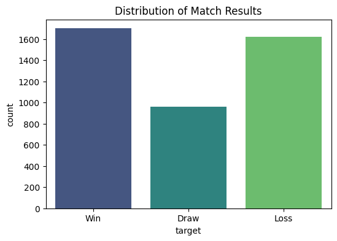

```python
# See if classes are balanced
plt.figure(figsize=(6, 4))
sns.countplot(x='target', data=df, order=['Win', 'Draw', 'Loss'], palette='viridis')
plt.title('Distribution of Match Results')
plt.show()
```

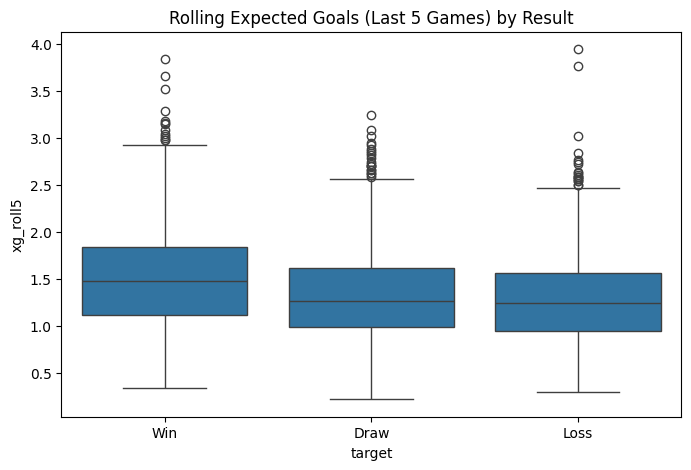

```python
# Boxplot to see if 'xg_roll5' (Expected Goals rolling avg) separates Wins from Losses
plt.figure(figsize=(8, 5))
sns.boxplot(x='target', y='xg_roll5', data=df, order=['Win', 'Draw', 'Loss'])
plt.title('Rolling Expected Goals (Last 5 Games) by Result')
plt.show()
```

# Exploratory Data Analysis

We will now perform some statistical tests to better understand how some of the variables in our dataset correlate with one another. We will investigate:

Question: Do teams win significantly more often when playing at home compared to away?

Method: Two sample z-test with win percantage at home versus away.

Hypothesis:

Hypothesis: H0: The proportion of home wins equals the proportion of away wins. H1: The proportion of home wins is greater than the proportion of away wins.

Testing type: Two-Sample Z-test See cells below for data visualization and test statistic computation, computed z-value = 6.61458, computed p-value of 0.00000.

Conclusion Found:

We reject H0; home teams win significantly more often (p = 0.00000 < 0.05). Thus, home field advantage significantly increases winning percentage.

```
Home wins: 1059/2392 = 0.44273
Away wins: 836/2394 = 0.34921
Z-statistic: 6.61458
P-value: 0.00000
```

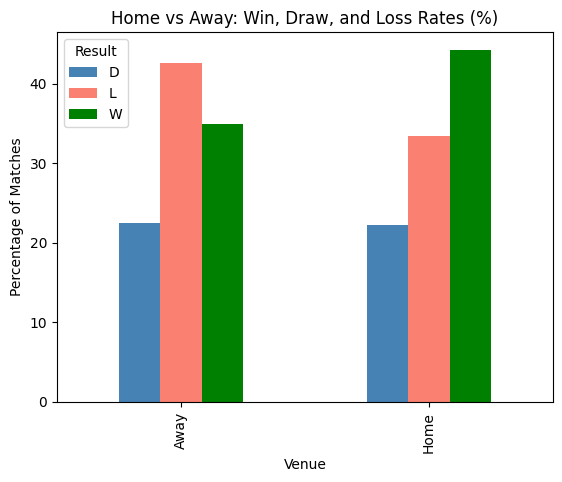

```python
#1: Do teams win more at home?
from statsmodels.stats.proportion import proportions_ztest

counts = explore_df.groupby(['venue', 'result']).size().unstack(fill_value=0)

rates = counts.div(counts.sum(axis=1), axis=0) * 100

home_wins = len(explore_df[(explore_df['venue'] == 'Home') & (explore_df['result'] == 'W')])
away_wins = len(explore_df[(explore_df['venue'] == 'Away') & (explore_df['result'] == 'W')])

home_games = len(explore_df[explore_df['venue'] == 'Home'])
away_games = len(explore_df[explore_df['venue'] == 'Away'])

hwhg = home_wins/home_games
awag = away_wins/away_games

print(f"Home wins: {home_wins}/{home_games} = {hwhg:.5f}")
print(f"Away wins: {away_wins}/{away_games} = {awag:.5f}")

#running two sample t-test
z_stat, p_val = proportions_ztest([home_wins, away_wins], [home_games, away_games], alternative='larger')

print(f"Z-statistic: {z_stat:.5f}")
print(f"P-value: {p_val:.5f}")


rates.plot(kind='bar', color=['steelblue', 'salmon', 'green'])
plt.title('Home vs Away: Win, Draw, and Loss Rates (%)')
plt.xlabel('Venue')
plt.ylabel('Percentage of Matches')
plt.legend(title='Result')
plt.show()
```

Question: Which performance features (shots, possession, fouls, etc.) correlate the most with home wins.

Hypothesis: H0: For each factor, there is no correlation between winning and losing. H1: There exists a factor such that affects the chance of winning significantly

```
result_code
{0: '0', 1: '1', 2: '2'}
                          MNLogit Regression Results
==============================================================================
Dep. Variable:            result_code   No. Observations:                 2392
Model:                        MNLogit   Df Residuals:                     2372
Method:                           MLE   Df Model:                           18
Date:                Wed, 10 Dec 2025   Pseudo R-squ.:                  0.4566
Time:                        02:51:04   Log-Likelihood:                -1379.9
converged:                       True   LL-Null:                       -2539.3
Covariance Type:            nonrobust   LLR p-value:                     0.000
=================================================================================
result_code=1       coef    std err          z      P>|z|      [0.025      0.975]
---------------------------------------------------------------------------------
const            -1.6302      0.675     -2.414      0.016      -2.954      -0.307
poss              0.0180      0.007      2.414      0.016       0.003       0.033
xg               -1.7819      0.217     -8.213      0.000      -2.207      -1.357
xga               0.2381      0.133      1.793      0.073      -0.022       0.498
ga                1.9449      0.118     16.486      0.000       1.714       2.176
sot              -0.4171      0.051     -8.179      0.000      -0.517      -0.317
sh                0.1621      0.026      6.150      0.000       0.110       0.214
fk               -0.1025      0.116     -0.882      0.378      -0.331       0.125
pk               -0.7476      0.308     -2.427      0.015      -1.352      -0.144
dist             -0.0346      0.030     -1.145      0.252      -0.094       0.025
---------------------------------------------------------------------------------
result_code=2       coef    std err          z      P>|z|      [0.025      0.975]
---------------------------------------------------------------------------------
const            -0.6833      0.581     -1.175      0.240      -1.823       0.456
poss              0.0017      0.006      0.273      0.785      -0.010       0.014
xg                1.0309      0.143      7.195      0.000       0.750       1.312
xga              -0.0357      0.118     -0.302      0.762      -0.267       0.196
ga               -1.3548      0.101    -13.394      0.000      -1.553      -1.157
sot               0.4562      0.041     11.248      0.000       0.377       0.536
sh               -0.1538      0.020     -7.592      0.000      -0.194      -0.114
fk               -0.0389      0.097     -0.403      0.687      -0.228       0.150
pk                0.8380      0.222      3.767      0.000       0.402       1.274
dist              0.0361      0.027      1.335      0.182      -0.017       0.089
=================================================================================

Likelihood Ratio Test:
LR stat = 2318.934, df = 18.0, p = 0
```

[figure not shown]

```python
#2: Which performance features correlate most with home wins?
import statsmodels.api as sm
import statsmodels.formula.api as smf
from scipy.stats import chi2

# 1. Keep only home games
home_df = explore_df[explore_df['venue'] == 'Home'].copy()

mapping = {'L': 1, 'D': 0, 'W': 2}
home_df['result_code'] = home_df['result'].map(mapping)
# Define the model formula — include all features
features = "poss + xg + xga + ga + sot + sh + fk + pk + dist"
formula = f"result ~ {features}"

X = home_df[[ 'poss','xg', 'xga', 'ga', 'sot', 'sh', 'fk', 'pk', 'dist']]

# 4. Add intercept term
X = sm.add_constant(X)

# 5. Fit multinomial logistic regression
model = sm.MNLogit(home_df['result_code'], X)
result = model.fit(method='newton', maxiter=200, disp=False)
print(result.model.endog_names)
print(result.model._ynames_map)
print(result.summary())

# Fit null model (intercept only)
X_null = sm.add_constant(pd.DataFrame({'const': 1}, index=home_df.index))
null_model = sm.MNLogit(home_df['result_code'], X_null)
null_result = null_model.fit(method='newton', disp=False)

# Likelihood ratio test
LR_stat = 2 * (result.llf - null_result.llf)
df_diff = result.df_model - null_result.df_model
p_value = chi2.sf(LR_stat, df_diff)

print(f"\nLikelihood Ratio Test:")
print(f"LR stat = {LR_stat:.3f}, df = {df_diff}, p = {p_value:.4g}")

#Lets plot the results!
# Drop the intercept if you want to focus on features
coef_df = result.params.drop(columns='const', errors='ignore')

# Transpose so features are rows
coef_plot = coef_df.T

# Plot grouped bars
order = coef_plot.abs().max(axis=1).sort_values(ascending=False).index
coef_plot.loc[order].plot(kind='bar', figsize=(10,6))
plt.axhline(0, color='black', linestyle='--', linewidth=1)
plt.title('Feature Coefficients by Outcome (vs Loss)')
plt.ylabel('Log-Odds Coefficient')
plt.xlabel('Feature (0=draw vs loss, 1=win vs loss)')
plt.xticks(rotation=45, ha='right')
plt.legend(title='Outcome vs Loss')
plt.tight_layout()
plt.show()
```

Question:

Does the goal differential feature strongly predict total points or final league position?

Method:

Pearson Correlation test between GD and points + league position

Hypothesis:

H0: There is no correlation between GD and league position

H1: There is a significant correlation between GD and league position

Conclusion Found:

With that, we are able to reject the null hypothesis and conclude that goal differential is a strong predictor of both total points and final league rank.

```
Pearson correlation between Goal Differential and Season Points: 0.7686 (p-value: 0.0000)
Pearson correlation between Goal Differential and Season Position: -0.8860 (p-value: 0.0000)
```

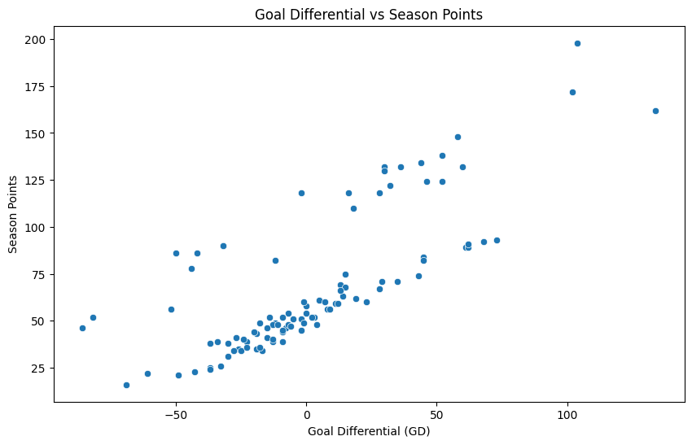

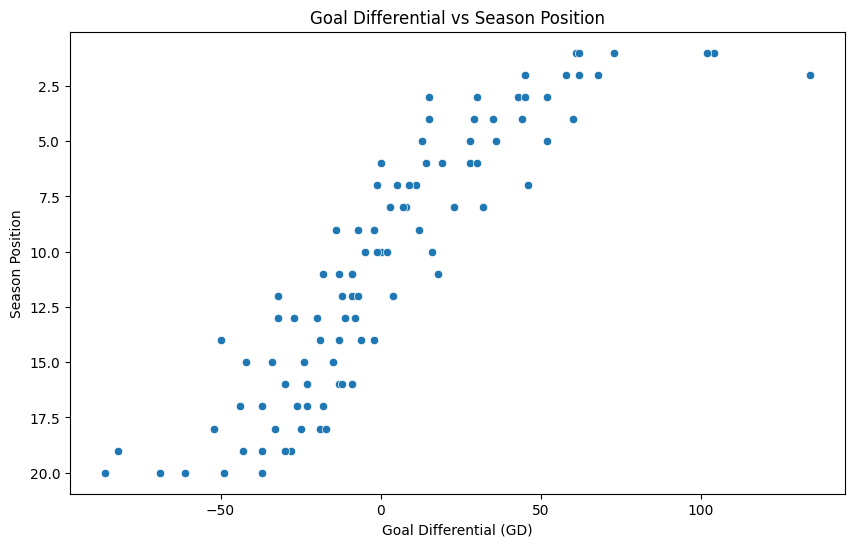

```python
#3: Does goal differential strongly predict total points or final league position?
season_stats = (
    explore_df.groupby(["season", "team"])
      .agg(
          goals_for=("gf", "sum"),
          goals_against=("ga", "sum"),
          wins=("result", lambda x: (x == "W").sum()),
          draws=("result", lambda x: (x == "D").sum()),
          losses=("result", lambda x: (x == "L").sum())
      )
      .reset_index()
)

# Compute derived features
season_stats["GD"] = season_stats["goals_for"] - season_stats["goals_against"]
season_stats["Points"] = 3 * season_stats["wins"] + season_stats["draws"]

# Rank teams by points for each season (lower rank = better)
season_stats["Position"] = season_stats.groupby("season")["Points"].rank(ascending=False, method="first")

from scipy.stats import pearsonr

# Drop rows with NaN values in GD, Points, or Position
season_stats_cleaned = season_stats.dropna(subset=["GD", "Points", "Position"])

# Calculate Pearson correlation between GD and Points
correlation_gd_points, p_value_gd_points = pearsonr(season_stats_cleaned["GD"], season_stats_cleaned["Points"])

# Calculate Pearson correlation between GD and Position
correlation_gd_position, p_value_gd_position = pearsonr(season_stats_cleaned["GD"], season_stats_cleaned["Position"])

print(f"Pearson correlation between Goal Differential and Season Points: {correlation_gd_points:.4f} (p-value: {p_value_gd_points:.4f})")
print(f"Pearson correlation between Goal Differential and Season Position: {correlation_gd_position:.4f} (p-value: {p_value_gd_position:.4f})")


#Lets plot the results!
# Scatter plot of Goal Differential vs Season Points
plt.figure(figsize=(10, 6))
sns.scatterplot(data=season_stats_cleaned, x="GD", y="Points")
plt.title("Goal Differential vs Season Points")
plt.xlabel("Goal Differential (GD)")
plt.ylabel("Season Points")
plt.show()

# Scatter plot of Goal Differential vs Season Position
plt.figure(figsize=(10, 6))
sns.scatterplot(data=season_stats_cleaned, x="GD", y="Position")
plt.title("Goal Differential vs Season Position")
plt.xlabel("Goal Differential (GD)")
plt.ylabel("Season Position")
plt.gca().invert_yaxis() # Invert y-axis for position (lower position is better)
plt.show()
```

# 4. Data Splitting & Processing

In sports analytics random splitting is inappropriate as it can cause random data leakages that we won't know how to account for. In our case we want to implement a temporal split as we do not want to use future matches to predict past ones.

With a temporal split we segrgeate the data based on the seasons with all the seasons prior to 2024 used for model training and the 2024 season remains used for model testing. This ensures that our evaluation metric best reflect the model's ability to predict future games.

```python
train_df = df[df["season"] < 2024]
test_df = df[df["season"] == 2024]

print(f"Shape of training data: {train_df.shape}")
print(f"Shape of testing data: {test_df.shape}")
```

```
Shape of training data: (3626, 26)
Shape of testing data: (660, 26)
```

The split results in 3,626 samples for training and 660 for testing. This provides a robust historical baseline for the model while reserving a full season's worth of games for evaluation, which is sufficient to smooth out variance from individual match upsets.

## Define Features and Preprocessing

Since machine learning alogrithims work absed on numerical data we need to convert our raw categorical data into something these algorithims can understand. To do this we apply one-hot encoding to our ategroical features where category now has two columsn for binary representation of the data thus allowing the model to learn distinct representations for each category without implying an oridinal relationship.

```python
numerical_features = [
    "xg", "xga", "hour", "day_code", "season",
    "gf_roll5", "ga_roll5", "xg_roll5", "xga_roll5",
    "sh_roll5", "sot_roll5", "poss_roll5", "goal_diff_roll5", "points_roll5"
]

categorical_features = [
    "team", "opponent", "venue", "day", "captain", "formation", "referee"
]

preprocessor = ColumnTransformer(
    transformers=[
        ('cat', OneHotEncoder(handle_unknown='ignore'), categorical_features),
        ('num', 'passthrough', numerical_features)
    ])

print("Numerical features defined:", numerical_features)
print("Categorical features defined:", categorical_features)
print("ColumnTransformer 'preprocessor' created successfully.")
```

```
Numerical features defined: ['xg', 'xga', 'hour', 'day_code', 'season', 'gf_roll5', 'ga_roll5', 'xg_roll5', 'xga_roll5', 'sh_roll5', 'sot_roll5', 'poss_roll5', 'goal_diff_roll5', 'points_roll5']
Categorical features defined: ['team', 'opponent', 'venue', 'day', 'captain', 'formation', 'referee']
ColumnTransformer 'preprocessor' created successfully.
```

By setting handle_unknown='ignore' in the encoder, we ensure the pipeline remains robust even if the test set (2024 season) introduces a new referee or formation not seen in the training history. This preprocessor is now ready to be integrated into a modeling pipeline.

# 5. Primary Analysis: Building Prediction Pipelines and Evaluations

## RANDOM FOREST PIPELINE

We make use of Scikit-Learn's Pipeline class to guarantee an efficient and repeatable approach. The machine learning model and our previously specified preprocessing are combined into one object by this wrapper. This simplifies the code for next predictions and stops "data leakage," which occurs when knowledge from the test set unintentionally seeps into the training process.

For this challenge, we have used the Random Forest Classifier. During training, Random Forests are ensemble learning techniques that build a large number of decision trees. Because they are resistant to overfitting and can manage the non-linear relationships frequently found in match statistics, they are especially well-suited for sports prediction.

```python
X_train = train_df[numerical_features + categorical_features]
y_train = train_df["target"]

# Create the pipeline
model_pipeline = Pipeline(steps=[('preprocessor', preprocessor),
                               ('classifier', RandomForestClassifier(random_state=42))])

# Train the model
model_pipeline.fit(X_train, y_train)

print("Machine learning pipeline created and trained successfully.")
```

```
Machine learning pipeline created and trained successfully.
```

## Evaluate Model Performance

```
Classification Report:
              precision    recall  f1-score   support

        Draw       0.55      0.04      0.08       145
        Loss       0.58      0.75      0.66       257
         Win       0.61      0.74      0.67       258

    accuracy                           0.59       660
   macro avg       0.58      0.51      0.47       660
weighted avg       0.58      0.59      0.53       660


Confusion Matrix:
[[  6  74  65]
 [  4 194  59]
 [  1  66 191]]
```

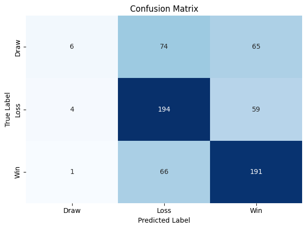

```python
X_test = test_df[numerical_features + categorical_features]
y_test = test_df["target"]

# Make predictions on the test set
y_pred = model_pipeline.predict(X_test)

# Evaluate the model
print("Classification Report:")
print(classification_report(y_test, y_pred))

print("\nConfusion Matrix:")
print(confusion_matrix(y_test, y_pred))

cm = confusion_matrix(y_test, y_pred)
plt.figure()
sns.heatmap(cm,annot=True,fmt="d",cmap="Blues", xticklabels=model_pipeline.classes_, yticklabels=model_pipeline.classes_,cbar=False)
plt.xlabel("Predicted Label")
plt.ylabel("True Label")
plt.title("Confusion Matrix")
plt.tight_layout()
plt.show()
```

## Visualizing the Significance of Features: The ability of tree-based models to identify the features that were most crucial in making predictions is one of their main advantages.

The top 20 most important characteristics are displayed in the plot below. The model's classification of a match as a Win, Loss, or Draw was more influenced by features with higher importance. This may provide unexpected insights or validate our intuition, for example, xg_roll5 should be significant.

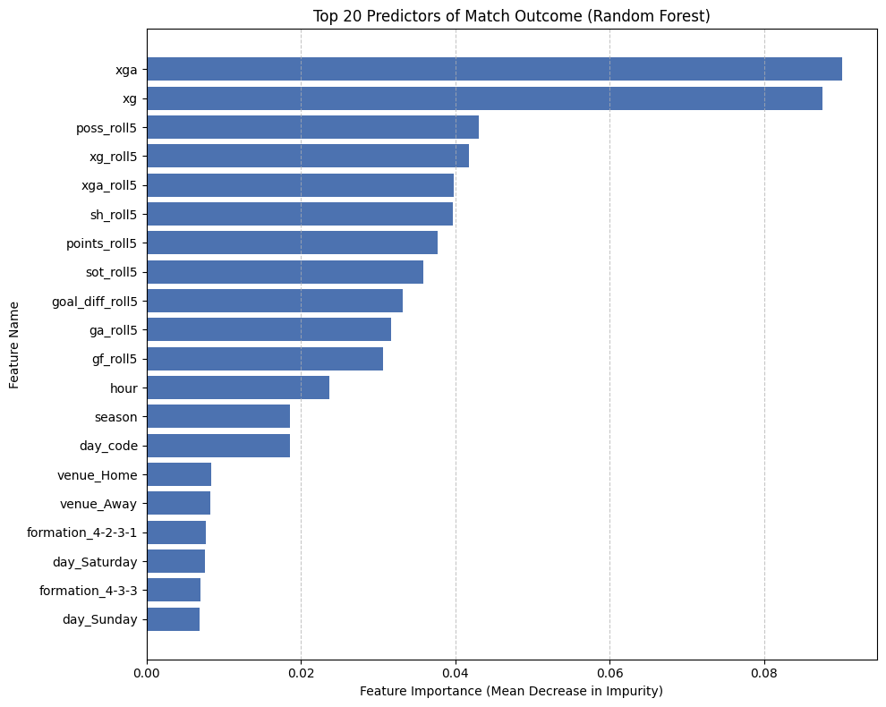

```python
rf_model = model_pipeline.named_steps['classifier']

preprocessor = model_pipeline.named_steps['preprocessor']
ohe_feature_names = preprocessor.named_transformers_['cat'].get_feature_names_out(categorical_features)
all_feature_names = np.concatenate([ohe_feature_names, numerical_features])

# Get feature importances from the model
importances = rf_model.feature_importances_

feature_imp_df = pd.DataFrame({
    'Feature': all_feature_names,
    'Importance': importances
}).sort_values(by='Importance', ascending=False)

# Plot the Top 20 most important features
plt.figure(figsize=(10, 8))
plt.barh(feature_imp_df['Feature'][:20], feature_imp_df['Importance'][:20], color='#4c72b0')
plt.xlabel("Feature Importance (Mean Decrease in Impurity)")
plt.ylabel("Feature Name")
plt.title("Top 20 Predictors of Match Outcome (Random Forest)")
plt.gca().invert_yaxis() # Put the most important feature at the top
plt.grid(axis='x', linestyle='--', alpha=0.7)
plt.tight_layout()
plt.show()
```

## Summary:

### Data Analysis Key Findings

- The 'points' column was successfully converted into a categorical 'target' variable with the following distribution: 1701 'Win', 1623 'Loss', and 962 'Draw'.
- The model achieved an overall accuracy of 0.59 on the test set.
- The model's performance varied significantly across the target classes:
  - 'Win': precision 0.61, recall 0.74, F1-score 0.67
  - 'Loss': precision 0.58, recall 0.75, F1-score 0.66
  - 'Draw': precision 0.55, recall 0.04, F1-score 0.08, indicating a significant challenge in correctly identifying draws.
- The confusion matrix further highlighted the difficulty in predicting 'Draw', with only 6 true positives for 'Draw' out of 145 actual draws in the test set.

### Insights or Next Steps

- The model struggles significantly with predicting 'Draw' outcomes. This could be due to an imbalanced dataset (fewer 'Draw' instances) or the inherent difficulty in distinguishing draws from wins/losses based on the current feature set. Further investigation into feature engineering or resampling techniques for the 'Draw' class is warranted.
- Consider exploring other classification algorithms or hyperparameter tuning for the `RandomForestClassifier` to potentially improve the recall for the 'Draw' class, as well as the overall model accuracy.

```python
df["abs_xg_diff"] = abs(df["xg"] - df["xga"])
df["abs_goal_diff_roll5"] = abs(df["gf_roll5"] - df["ga_roll5"])

print(df[["xg", "xga", "abs_xg_diff", "gf_roll5", "ga_roll5", "abs_goal_diff_roll5"]].head())
```

```
    xg  xga  abs_xg_diff  gf_roll5  ga_roll5  abs_goal_diff_roll5
5  2.4  1.5          0.9       1.6       1.6                  0.0
6  1.9  0.9          1.0       2.0       2.0                  0.0
7  1.2  0.6          0.6       1.8       2.0                  0.2
8  1.0  0.9          0.1       1.8       1.4                  0.4
9  1.3  1.6          0.3       1.4       1.2                  0.2
```

```python
numerical_features.extend(["abs_xg_diff", "abs_goal_diff_roll5"])

print("Updated numerical features:", numerical_features)
```

```
Updated numerical features: ['xg', 'xga', 'hour', 'day_code', 'season', 'gf_roll5', 'ga_roll5', 'xg_roll5', 'xga_roll5', 'sh_roll5', 'sot_roll5', 'poss_roll5', 'goal_diff_roll5', 'points_roll5', 'abs_xg_diff', 'abs_goal_diff_roll5']
```

We need to re-split the data and re-train the pipeline after adding our new features to the dataset to make sure the new columns are part of the training set. To ensure a fair comparison, we keep the same temporal divide.

```python
train_df = df[df["season"] < 2024]
test_df = df[df["season"] == 2024]

print(f"Shape of training data: {train_df.shape}")
print(f"Shape of testing data: {test_df.shape}")
```

```
Shape of training data: (3626, 28)
Shape of testing data: (660, 28)
```

```python
preprocessor = ColumnTransformer(
    transformers=[
        ('cat', OneHotEncoder(handle_unknown='ignore'), categorical_features),
        ('num', 'passthrough', numerical_features)
    ])

print("ColumnTransformer 'preprocessor' recreated successfully with updated features.")
```

```
ColumnTransformer 'preprocessor' recreated successfully with updated features.
```

```python
X_train = train_df[numerical_features + categorical_features]
y_train = train_df["target"]

# Create the pipeline with the updated preprocessor
model_pipeline = Pipeline(steps=[('preprocessor', preprocessor),
                               ('classifier', RandomForestClassifier(random_state=42))])

# Train the model with the updated training data
model_pipeline.fit(X_train, y_train)

print("Machine learning pipeline re-trained successfully with updated features.")
```

```
Machine learning pipeline re-trained successfully with updated features.
```

```
Classification Report:
              precision    recall  f1-score   support

        Draw       0.44      0.05      0.09       145
        Loss       0.61      0.77      0.68       257
         Win       0.62      0.77      0.69       258

    accuracy                           0.61       660
   macro avg       0.55      0.53      0.48       660
weighted avg       0.57      0.61      0.55       660


Confusion Matrix:
[[  7  73  65]
 [  4 197  56]
 [  5  55 198]]
```

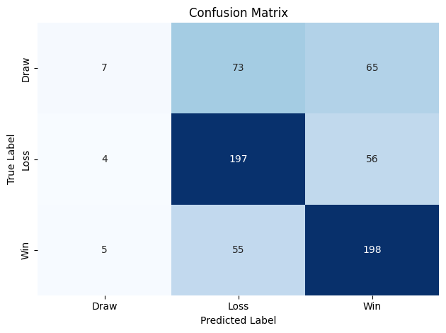

```python
X_test = test_df[numerical_features + categorical_features]
y_test = test_df["target"]

# Make predictions on the test set
y_pred = model_pipeline.predict(X_test)

# Evaluate the model
print("Classification Report:")
print(classification_report(y_test, y_pred))

print("\nConfusion Matrix:")
print(confusion_matrix(y_test, y_pred))

cm = confusion_matrix(y_test, y_pred)
plt.figure()
sns.heatmap(cm,annot=True,fmt="d",cmap="Blues", xticklabels=model_pipeline.classes_, yticklabels=model_pipeline.classes_,cbar=False)
plt.xlabel("Predicted Label")
plt.ylabel("True Label")
plt.title("Confusion Matrix")
plt.tight_layout()
plt.show()
```

## Summary:

### Q&A

Despite these minor changes, the model continues to struggle significantly with accurately predicting 'Draw' outcomes, as evidenced by the persistently low recall and F1-score for this class.

### Insights or Next Steps

- While the new features improved overall accuracy, they did not substantially address the model's primary weakness in predicting 'Draw' outcomes. Further feature engineering should focus on signals more indicative of a draw.

To address this class imbalance and improved decision boundary, we will next explore a linear model: Logistic Regression.

**TRAIN LOG REG**

Despite feature engineering, our Random Forest model continued to ignore the "Draw" class. The model optimizes for overall accuracy by merely predicting the majority classes ,Win/Loss, which is a common problem when one class is much smaller than the others.

We use a Logistic Regression model to combat this. In contrast to the Random Forest that was previously employed, we will specifically set `class_weight`='balanced'. This input tells the model to modify the loss function so that errors on the minority class ,Draws, are penalized more severely than errors on the majority classes. This should ideally compel the model to "pay attention" to games that are tied.

```python
from sklearn.linear_model import LogisticRegression

print("LogisticRegression imported successfully.")
```

```
LogisticRegression imported successfully.
```

```python
lr_pipeline = Pipeline(steps=[('preprocessor', preprocessor),
                               ('classifier', LogisticRegression(class_weight='balanced', random_state=42, solver='liblinear'))])

lr_pipeline.fit(X_train, y_train)

print("Logistic Regression pipeline created and trained successfully.")
```

```
Logistic Regression pipeline created and trained successfully.
```

## Logistic Regression Coefficient Visualization

Logistic regression is much easier to understand than the hidden functonality of complex models. For each feature, the model learns a particular coefficient, or weight. Positive Coefficients: Raise the positive class's log-odds (for example, a higher xg increases the likelihood of a "Win"). Negative Coefficients: Reduce the log-odds (for example, a higher xga reduces the likelihood of a "Win"). The top coefficients influencing the model's decision-making are shown in the plot below. This enables us to determine precisely which statistics the model is "betting on."

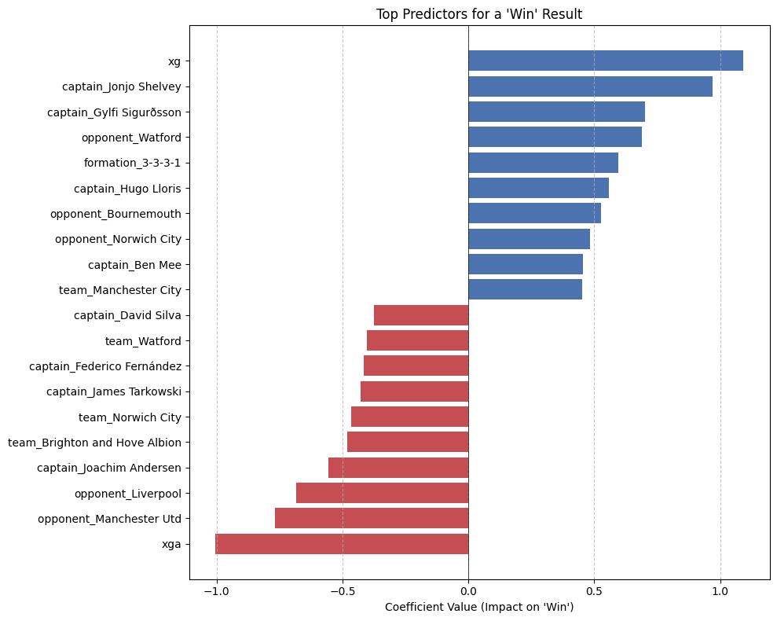

```python
lr_model = lr_pipeline.named_steps['classifier']
preprocessor = lr_pipeline.named_steps['preprocessor']

ohe_feature_names = preprocessor.named_transformers_['cat'].get_feature_names_out(categorical_features)
all_feature_names = np.concatenate([ohe_feature_names, numerical_features])

# Logistic Regression for multi-class (Win, Draw, Loss) has a shape of (3, n_features)
# We will focus on the coefficients for the 'Win' class (index 2 usually, check model.classes_)
target_class = "Win"
class_index = list(lr_model.classes_).index(target_class)
coefficients = lr_model.coef_[class_index]

coef_df = pd.DataFrame({
    'Feature': all_feature_names,
    'Coefficient': coefficients
}).sort_values(by='Coefficient', ascending=False)

# Plot the top positive and negative correlations
top_positive = coef_df.head(10)
top_negative = coef_df.tail(10)
plot_df = pd.concat([top_positive, top_negative])

plt.figure(figsize=(10, 8))
colors = ['#4c72b0' if c > 0 else '#c44e52' for c in plot_df['Coefficient']]
plt.barh(plot_df['Feature'], plot_df['Coefficient'], color=colors)
plt.xlabel(f"Coefficient Value (Impact on '{target_class}')")
plt.title(f"Top Predictors for a '{target_class}' Result")
plt.axvline(x=0, color='black', linestyle='-', linewidth=0.5)
plt.grid(axis='x', linestyle='--', alpha=0.7)
plt.gca().invert_yaxis()
plt.tight_layout()
plt.show()
```

## Evaluate Logistic Regression Model

```
Logistic Regression Classification Report:
              precision    recall  f1-score   support

        Draw       0.33      0.26      0.29       145
        Loss       0.62      0.72      0.67       257
         Win       0.69      0.66      0.67       258

    accuracy                           0.60       660
   macro avg       0.55      0.55      0.54       660
weighted avg       0.58      0.60      0.59       660


Logistic Regression Confusion Matrix:
[[ 38  61  46]
 [ 41 185  31]
 [ 36  52 170]]
```

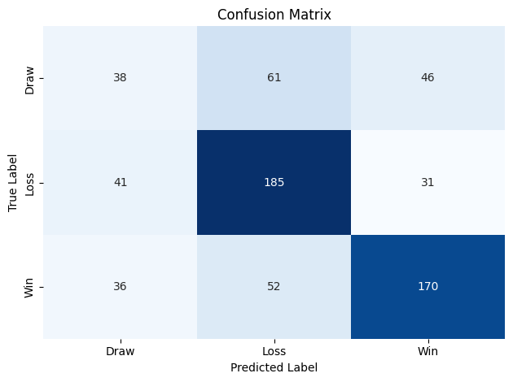

```python
y_pred_lr = lr_pipeline.predict(X_test)

print("Logistic Regression Classification Report:")
print(classification_report(y_test, y_pred_lr))

print("\nLogistic Regression Confusion Matrix:")
print(confusion_matrix(y_test, y_pred_lr))

cm = confusion_matrix(y_test, y_pred_lr)
plt.figure()
sns.heatmap(cm,annot=True,fmt="d",cmap="Blues", xticklabels=lr_pipeline.classes_, yticklabels=lr_pipeline.classes_,cbar=False)
plt.xlabel("Predicted Label")
plt.ylabel("True Label")
plt.title("Confusion Matrix")
plt.tight_layout()
plt.show()
```

These results present the classic data science case of the trade-off between accuracy and recall. The Logistic Regression model achieved a recall of 0,26 correctly identifying 38 draws which is a drastic improvement compared to the Random Forest. However, the overall accuracy dropped slightly to 60% as the model is taking more risks to predict Draws hence making more mistakes on Wins and Losses.

Therefore, while the Random Forest is techincally more accurate on paper the Logistic Regression model is arguably more useful as it seems to understand the nuance of the game better and analyze patterns that weren't there before with Random Forest for just a 1% decrease in the accuracy on paper.

## Train SVM Model

We use a Support Vector Machine (SVM) as a last experiment. In high-dimensional space, SVMs are effective at locating intricate decision boundaries.

We need to update our ColumnTransformer to incorporate a StandardScaler for the numerical features in order to avoid this. This sets the mean and standard deviation of all numerical inputs to 0 and 1, respectively.

```python
from sklearn.svm import SVC

print("SVC imported successfully.")
```

```
SVC imported successfully.
```

```python
import pandas as pd
import numpy as np

from sklearn.ensemble import RandomForestClassifier
from sklearn.compose import ColumnTransformer
from sklearn.preprocessing import OneHotEncoder, StandardScaler
from sklearn.pipeline import Pipeline
from sklearn.metrics import classification_report, confusion_matrix

import matplotlib.pyplot as plt
```

```python
preprocessor = ColumnTransformer(
    transformers=[
        ('cat', OneHotEncoder(handle_unknown='ignore'), categorical_features),
        ('num', StandardScaler(), numerical_features)
    ])

print("ColumnTransformer 'preprocessor' recreated successfully with StandardScaler for numerical features.")
```

```
ColumnTransformer 'preprocessor' recreated successfully with StandardScaler for numerical features.
```

```python
svm_pipeline = Pipeline(steps=[('preprocessor', preprocessor),
                               ('classifier', SVC(class_weight='balanced', random_state=42))])

svm_pipeline.fit(X_train, y_train)

print("SVM pipeline re-trained successfully with scaled features.")
```

```
SVM pipeline re-trained successfully with scaled features.
```

## Visualizing SVM Feature Importance (Permutation Method)

Our SVM has no linear coefficients to plot because it employs a non-linear RBF kernel, in contrast to Logistic Regression. It is impossible to directly visualize the model because it exists in a high-dimensional space.

We use Permutation Importance to determine which features influence the SVM's choices. Using this method, one feature column in the test set is shuffled at random, and the accuracy of the model is then measured. Large Drop: The prediction relied heavily on this feature. Zero/Small Drop: This feature was hardly utilized by the model.

### Interpretation of Permutation Importance

The "Drop" Metric: The percentage of accuracy lost when a feature is corrupted is shown on the X-axis. For instance, if `xg_roll5` is 0.05, then eliminating that data results in a 5% decrease in accuracy. Comparing This Model with Others: Are these characteristics the same as those found in the Random Forest? The SVM's performance was significantly different if it relies on entirely different features.

Negative Values Bars may appear somewhat negative. This simply indicates that the noisy feature was probably irrelevant or confusing to the SVM because shuffling it actually improved the model by chance.

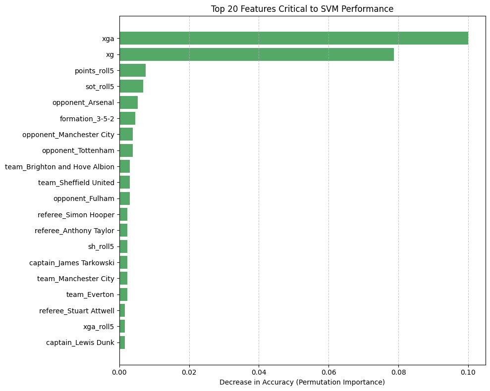

```python
from sklearn.inspection import permutation_importance
import matplotlib.pyplot as plt
import pandas as pd
import numpy as np

# 1. Transform the test data MANUALLY first
preprocessor_svm = svm_pipeline.named_steps['preprocessor']
X_test_transformed = preprocessor_svm.transform(X_test)

# --- THE FIX FOR THE FIRST ERROR ---
# Convert the sparse matrix to a standard dense array
# This satisfies the "array-like" requirement of permutation_importance
if hasattr(X_test_transformed, "toarray"):
    X_test_transformed = X_test_transformed.toarray()

# 2. Run Permutation Importance on the CLASSIFIER step only
# Now we pass the dense, transformed data
classifier_svm = svm_pipeline.named_steps['classifier']
perm_importance = permutation_importance(
    classifier_svm, X_test_transformed, y_test, n_repeats=2, random_state=42, n_jobs=-1
)

# 3. Get feature names matching the transformed data
ohe_feature_names = preprocessor_svm.named_transformers_['cat'].get_feature_names_out(categorical_features)
all_feature_names = np.concatenate([ohe_feature_names, numerical_features])

# 4. Create DataFrame (Now lengths are guaranteed to match!)
svm_imp_df = pd.DataFrame({
    'Feature': all_feature_names,
    'Importance': perm_importance.importances_mean
}).sort_values(by='Importance', ascending=False)

# 5. Plot Top 20 Features
plt.figure(figsize=(10, 8))
plt.barh(svm_imp_df['Feature'][:20], svm_imp_df['Importance'][:20], color='#55a868')
plt.xlabel("Decrease in Accuracy (Permutation Importance)")
plt.title("Top 20 Features Critical to SVM Performance")
plt.gca().invert_yaxis()
plt.grid(axis='x', linestyle='--', alpha=0.7)
plt.tight_layout()
plt.show()
```

```
SVM Classification Report (with scaling):
              precision    recall  f1-score   support

        Draw       0.32      0.33      0.32       145
        Loss       0.64      0.65      0.65       257
         Win       0.67      0.64      0.65       258

    accuracy                           0.58       660
   macro avg       0.54      0.54      0.54       660
weighted avg       0.58      0.58      0.58       660


SVM Confusion Matrix (with scaling):
[[ 48  51  46]
 [ 53 168  36]
 [ 51  42 165]]
```

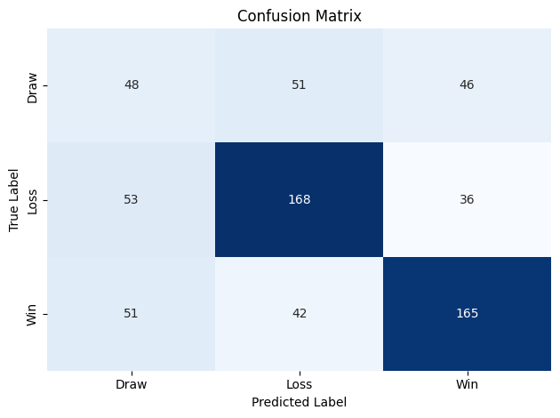

```python
y_pred_svm = svm_pipeline.predict(X_test)

print("SVM Classification Report (with scaling):")
print(classification_report(y_test, y_pred_svm))

print("\nSVM Confusion Matrix (with scaling):")
print(confusion_matrix(y_test, y_pred_svm))

cm = confusion_matrix(y_test, y_pred_svm)
plt.figure()
sns.heatmap(cm,annot=True,fmt="d",cmap="Blues", xticklabels=svm_pipeline.classes_, yticklabels=svm_pipeline.classes_,cbar=False)
plt.xlabel("Predicted Label")
plt.ylabel("True Label")
plt.title("Confusion Matrix")
plt.tight_layout()
plt.show()
```

## Model Performance Comparison

To compare the performance of the Random Forest, Logistic Regression, and SVM models, we will review their key metrics:

### 1. Random Forest Model Performance (with new features):

- **Overall Accuracy:** 0.61
- **Classification Report:**
  - **Draw:** Precision: 0.44, Recall: 0.05, F1-score: 0.09
  - **Loss:** Precision: 0.61, Recall: 0.77, F1-score: 0.68
  - **Win:** Precision: 0.62, Recall: 0.77, F1-score: 0.69

### 2. Logistic Regression Model Performance (with class_weight='balanced'):

- **Overall Accuracy:** 0.60
- **Classification Report:**
  - **Draw:** Precision: 0.33, Recall: 0.26, F1-score: 0.29
  - **Loss:** Precision: 0.62, Recall: 0.72, F1-score: 0.67
  - **Win:** Precision: 0.69, Recall: 0.66, F1-score: 0.67

### 3. SVM Model Performance (with StandardScaler and class_weight='balanced'):

- **Overall Accuracy:** 0.58
- **Classification Report:**
  - **Draw:** Precision: 0.32, Recall: 0.33, F1-score: 0.32
  - **Loss:** Precision: 0.64, Recall: 0.65, F1-score: 0.65
  - **Win:** Precision: 0.67, Recall: 0.64, F1-score: 0.65

### Comprehensive Comparison:

| Metric | Random Forest | Logistic Regression | SVM |
| --- | --- | --- | --- |
| **Overall Accuracy** | 0.61 | 0.60 | 0.58 |
| **Draw - Precision** | 0.44 | 0.33 | 0.32 |
| **Draw - Recall** | 0.05 | 0.26 | 0.33 |
| **Draw - F1-score** | 0.09 | 0.29 | 0.32 |
| **Loss - Precision** | 0.61 | 0.62 | 0.64 |
| **Loss - Recall** | 0.77 | 0.72 | 0.65 |
| **Loss - F1-score** | 0.68 | 0.67 | 0.65 |
| **Win - Precision** | 0.62 | 0.69 | 0.67 |
| **Win - Recall** | 0.77 | 0.66 | 0.64 |
| **Win - F1-score** | 0.69 | 0.67 | 0.65 |

### Which model performs best for 'Draw' predictions?

Based on the recall and F1-score, the **SVM model** performs best for predicting 'Draw' outcomes:

- **SVM:** Recall = 0.33, F1-score = 0.32
- **Logistic Regression:** Recall = 0.26, F1-score = 0.29
- **Random Forest:** Recall = 0.05, F1-score = 0.09

The Random Forest model still struggles significantly with 'Draw' predictions, showing very low recall, meaning it identifies very few actual draws. The Logistic Regression and SVM models, both utilizing `class_weight='balanced'`, show improved recall and F1-scores for the 'Draw' class compared to Random Forest.

### Key Strengths and Weaknesses:

- **Random Forest:**
  - **Strengths:** Highest overall accuracy and strong performance for 'Win' and 'Loss' predictions (high recall and F1-score). It handles non-linear relationships well.
  - **Weaknesses:** Extremely poor performance in predicting 'Draw' outcomes (very low recall and F1-score for 'Draw').
- **Logistic Regression:**
  - **Strengths:** Better at predicting 'Draw' outcomes than Random Forest (higher recall and F1-score for 'Draw'). Decent overall accuracy.
  - **Weaknesses:** Slightly lower overall accuracy than Random Forest. Performance for 'Win' and 'Loss' is good, but not as high as Random Forest's recall.
- **SVM:**
  - **Strengths:** Best performance in predicting 'Draw' outcomes (highest recall and F1-score for 'Draw') among the three models. The `StandardScaler` was crucial for its performance.
  - **Weaknesses:** Lowest overall accuracy among the three models. Performance for 'Win' and 'Loss' is lower than Random Forest and Logistic Regression. SVMs can also be computationally expensive for large datasets.

**In summary, while Random Forest achieved the highest overall accuracy, the SVM model, with appropriate scaling and class weighting, demonstrated the best ability to identify 'Draw' outcomes, which was a specific challenge across all models.**

### Comprehensive Comparison:

[output not shown]

### Next Steps:

- The persistent challenge in predicting 'Draw' outcomes suggests that simply adding more ratio-based features might not be enough. More sophisticated feature engineering or alternative modeling strategies might be necessary.
- Explore different techniques to handle class imbalance, such as advanced oversampling/undersampling methods beyond `class_weight='balanced'`.
- Investigate other types of features that might capture the nuances leading to a draw, such as defensive statistics, team form dynamics, or specific match situations.
- Consider ensemble methods or more complex neural network architectures if the current models continue to struggle with this imbalance and minority class prediction.

## Calculate Rolling Season Record

### Objective:

We want to calculate a new feature `rolling_season_record` for each team within each season. This feature will represent the team's record up to the current game, calculated as `(previous_wins + 0.5 * previous_draws) / total_previous_games_played`. This will require cumulative sums of wins, draws, and games played, shifted by one to avoid data leakage.

```python
df["wins"] = (df["target"] == "Win").astype(int)
df["draws"] = (df["target"] == "Draw").astype(int)
df["total_games_played"] = 1

print(df[["target", "wins", "draws", "total_games_played"]].head())
```

```
  target  wins  draws  total_games_played
5    Win     1      0                   1
6   Draw     0      1                   1
7    Win     1      0                   1
8   Loss     0      0                   1
9   Draw     0      1                   1
```

```python
grouped = df.groupby(['team', 'season'], observed=False)

df["previous_wins"] = grouped["wins"].cumsum().shift(1)
df["previous_draws"] = grouped["draws"].cumsum().shift(1)
df["total_previous_games_played"] = grouped["total_games_played"].cumsum().shift(1)

# Fill NaN values (which occur for the first game of each season for each team) with 0
df["previous_wins"] = df["previous_wins"].fillna(0)
df["previous_draws"] = df["previous_draws"].fillna(0)
df["total_previous_games_played"] = df["total_previous_games_played"].fillna(0)

# Calculate rolling_season_record, handling division by zero for initial games
df["rolling_season_record"] = np.where(
    df["total_previous_games_played"] > 0,
    (df["previous_wins"] + 0.5 * df["previous_draws"]) / df["total_previous_games_played"],
    0  # Assign 0 for the first game of the season or if no previous games
)

# Display the new feature and its components
print(df[["team", "season", "date", "target", "wins", "draws", "total_games_played",
          "previous_wins", "previous_draws", "total_previous_games_played",
          "rolling_season_record"]].head(10))
```

```
       team  season       date target  wins  draws  total_games_played  \
5   Arsenal    2020 2019-09-22    Win     1      0                   1
6   Arsenal    2020 2019-09-30   Draw     0      1                   1
7   Arsenal    2020 2019-10-06    Win     1      0                   1
8   Arsenal    2020 2019-10-21   Loss     0      0                   1
9   Arsenal    2020 2019-10-27   Draw     0      1                   1
10  Arsenal    2020 2019-11-02   Draw     0      1                   1
11  Arsenal    2020 2019-11-09   Loss     0      0                   1
12  Arsenal    2020 2019-11-23   Draw     0      1                   1
13  Arsenal    2020 2019-12-01   Draw     0      1                   1
14  Arsenal    2020 2019-12-05   Loss     0      0                   1

    previous_wins  previous_draws  total_previous_games_played  \
5             0.0             0.0                          0.0
6             1.0             0.0                          1.0
```

[output cut: 20 more lines]

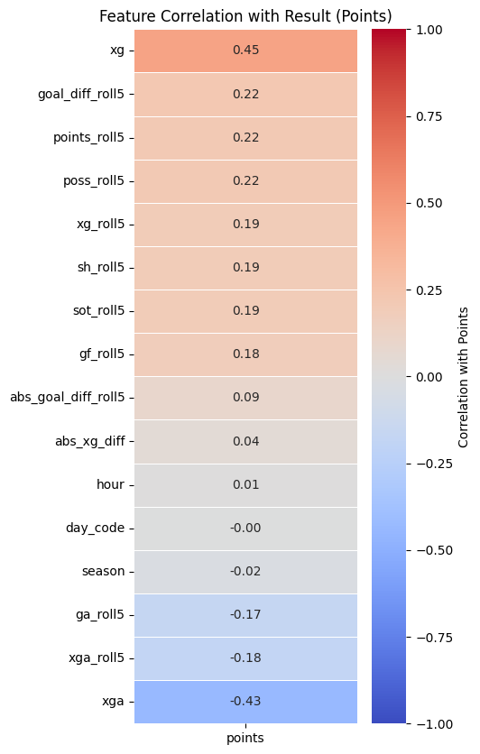

```python
#Heatmap
cols_to_analyze = numerical_features + ['points']
corr_with_target = df[cols_to_analyze].corr()[['points']].sort_values(by='points', ascending=False)
corr_with_target = corr_with_target.drop('points')
plt.figure(figsize=(4, 10))
sns.heatmap(corr_with_target,
            annot=True,
            fmt=".2f",
            cmap='coolwarm',
            linewidths=0.5,
            vmin=-1, vmax=1,
            cbar_kws={'label': 'Correlation with Points'})

plt.title('Feature Correlation with Result (Points)')
plt.show()
```

```python
numerical_features.append("rolling_season_record")
leakage = ['xg', 'xga', 'season', 'hour', 'day_code']
numerical_features = [col for col in numerical_features if col not in leakage]

print("Updated numerical features:", numerical_features)
print(df[['team', 'season', 'date', 'target', 'rolling_season_record']].head())
```

```
Updated numerical features: ['gf_roll5', 'ga_roll5', 'xg_roll5', 'xga_roll5', 'sh_roll5', 'sot_roll5', 'poss_roll5', 'goal_diff_roll5', 'points_roll5', 'abs_xg_diff', 'abs_goal_diff_roll5', 'rolling_season_record']
      team  season       date target  rolling_season_record
5  Arsenal    2020 2019-09-22    Win               0.000000
6  Arsenal    2020 2019-09-30   Draw               1.000000
7  Arsenal    2020 2019-10-06    Win               0.750000
8  Arsenal    2020 2019-10-21   Loss               0.833333
9  Arsenal    2020 2019-10-27   Draw               0.625000
```

## Re-split Data

Now we re-divide the dataset into training and testing sets based on the 'season' column, ensuring the new `rolling_season_record` feature is included.

We will filter the DataFrame `df` based on the 'season' column to create `train_df` for seasons before 2024 and `test_df` for the 2024 season, then print their shapes for verification.

```python
train_df = df[df["season"] < 2024]
test_df = df[df["season"] == 2024]

print(f"Shape of training data: {train_df.shape}")
print(f"Shape of testing data: {test_df.shape}")
```

```
Shape of training data: (3626, 35)
Shape of testing data: (660, 35)
```

## Redefine Preprocessor (Imputer & Scaler)

Redefine the `ColumnTransformer` to include `SimpleImputer(strategy='mean')` for numerical features, followed by a `StandardScaler`. This will handle any NaN values from new features and ensure proper scaling for all numerical features. Afterwards we redefine the `ColumnTransformer` named `preprocessor` to include `OneHotEncoder` for categorical features and a `Pipeline` of `SimpleImputer` and `StandardScaler` for numerical features

```python
from sklearn.impute import SimpleImputer

print("SimpleImputer imported successfully.")
```

```
SimpleImputer imported successfully.
```

```python
preprocessor = ColumnTransformer(
    transformers=[
        ('cat', OneHotEncoder(handle_unknown='ignore'), categorical_features),
        ('num', Pipeline(steps=[('imputer', SimpleImputer(strategy='mean')),
                               ('scaler', StandardScaler())]), numerical_features)
    ])

print("ColumnTransformer 'preprocessor' redefined successfully with SimpleImputer and StandardScaler.")
```

```
ColumnTransformer 'preprocessor' redefined successfully with SimpleImputer and StandardScaler.
```

## Random Forest Model

```python
X_train = train_df[numerical_features + categorical_features]
y_train = train_df["target"]

# Create the Random Forest pipeline with the updated preprocessor
rf_pipeline = Pipeline(steps=[('preprocessor', preprocessor),
                               ('classifier', RandomForestClassifier(random_state=42))])

# Train the model with the updated training data
rf_pipeline.fit(X_train, y_train)

print("Random Forest pipeline re-trained successfully with new features and preprocessing.")
```

```
Random Forest pipeline re-trained successfully with new features and preprocessing.
```

Now that the Random Forest model has been re-trained with the new features and updated preprocessing, we will evaluate its performance on the test set by making predictions and generating a classification report and a confusion matrix.

```
Random Forest Classification Report (with new feature and scaling):
              precision    recall  f1-score   support

        Draw       0.33      0.04      0.07       145
        Loss       0.52      0.68      0.59       257
         Win       0.53      0.63      0.57       258

    accuracy                           0.52       660
   macro avg       0.46      0.45      0.41       660
weighted avg       0.48      0.52      0.47       660


Random Forest Confusion Matrix (with new feature and scaling):
[[  6  68  71]
 [  7 175  75]
 [  5  91 162]]
```

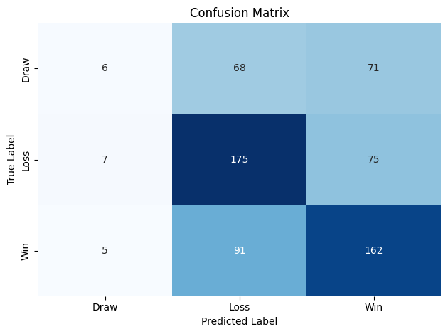

```python
X_test = test_df[numerical_features + categorical_features]
y_test = test_df["target"]

# Make predictions on the test set
y_pred_rf = rf_pipeline.predict(X_test)

# Evaluate the model
print("Random Forest Classification Report (with new feature and scaling):")
print(classification_report(y_test, y_pred_rf))

print("\nRandom Forest Confusion Matrix (with new feature and scaling):")
print(confusion_matrix(y_test, y_pred_rf))

cm = confusion_matrix(y_test, y_pred_rf)
plt.figure()
sns.heatmap(cm,annot=True,fmt="d",cmap="Blues", xticklabels=rf_pipeline.classes_, yticklabels=rf_pipeline.classes_,cbar=False)
plt.xlabel("Predicted Label")
plt.ylabel("True Label")
plt.title("Confusion Matrix")
plt.tight_layout()
plt.show()
```

**LOGISTIC REGRESSION PIPELINE**

```python
X_train = train_df[numerical_features + categorical_features]
y_train = train_df["target"]

# Create the Logistic Regression pipeline with the updated preprocessor
lr_pipeline = Pipeline(steps=[('preprocessor', preprocessor),
                               ('classifier', LogisticRegression(class_weight='balanced', random_state=42, solver='liblinear'))])

# Train the model with the updated training data
lr_pipeline.fit(X_train, y_train)

print("Logistic Regression pipeline re-trained successfully with new features and preprocessing.")
```

```
Logistic Regression pipeline re-trained successfully with new features and preprocessing.
```

```
Logistic Regression Classification Report (with new feature and scaling):
              precision    recall  f1-score   support

        Draw       0.32      0.28      0.30       145
        Loss       0.54      0.66      0.60       257
         Win       0.62      0.52      0.56       258

    accuracy                           0.52       660
   macro avg       0.49      0.49      0.49       660
weighted avg       0.52      0.52      0.52       660


Logistic Regression Confusion Matrix (with new feature and scaling):
[[ 41  65  39]
 [ 43 170  44]
 [ 46  78 134]]
```

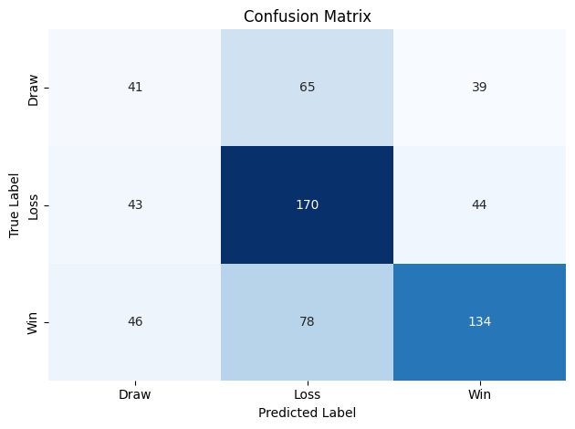

```python
X_test = test_df[numerical_features + categorical_features]
y_test = test_df["target"]

# Make predictions on the test set
y_pred_lr = lr_pipeline.predict(X_test)

# Evaluate the model
print("Logistic Regression Classification Report (with new feature and scaling):")
print(classification_report(y_test, y_pred_lr))

print("\nLogistic Regression Confusion Matrix (with new feature and scaling):")
print(confusion_matrix(y_test, y_pred_lr))

cm = confusion_matrix(y_test, y_pred_lr)
plt.figure()
sns.heatmap(cm,annot=True,fmt="d",cmap="Blues", xticklabels=lr_pipeline.classes_, yticklabels=lr_pipeline.classes_,cbar=False)
plt.xlabel("Predicted Label")
plt.ylabel("True Label")
plt.title("Confusion Matrix")
plt.tight_layout()
plt.show()
```

**SVM MODEL PIPELINE**

```python
X_train = train_df[numerical_features + categorical_features]
y_train = train_df["target"]

# Create the SVM pipeline with the updated preprocessor
svm_pipeline = Pipeline(steps=[('preprocessor', preprocessor),
                               ('classifier', SVC(class_weight='balanced', random_state=42))])

# Train the model with the updated training data
svm_pipeline.fit(X_train, y_train)

print("SVM pipeline re-trained successfully with new features and preprocessing.")
```

```
SVM pipeline re-trained successfully with new features and preprocessing.
```

```
SVM Classification Report (with new feature and scaling):
              precision    recall  f1-score   support

        Draw       0.31      0.41      0.35       145
        Loss       0.54      0.57      0.56       257
         Win       0.65      0.50      0.56       258

    accuracy                           0.51       660
   macro avg       0.50      0.49      0.49       660
weighted avg       0.53      0.51      0.51       660


SVM Confusion Matrix (with new feature and scaling):
[[ 59  57  29]
 [ 69 147  41]
 [ 63  67 128]]
```

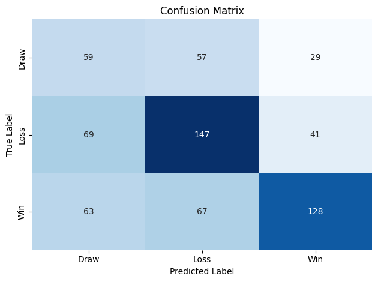

```python
X_test = test_df[numerical_features + categorical_features]
y_test = test_df["target"]

# Make predictions on the test set
y_pred_svm = svm_pipeline.predict(X_test)

# Evaluate the model
print("SVM Classification Report (with new feature and scaling):")
print(classification_report(y_test, y_pred_svm))

print("\nSVM Confusion Matrix (with new feature and scaling):")
print(confusion_matrix(y_test, y_pred_svm))

cm = confusion_matrix(y_test, y_pred_svm)
plt.figure()
sns.heatmap(cm,annot=True,fmt="d",cmap="Blues", xticklabels=svm_pipeline.classes_, yticklabels=svm_pipeline.classes_,cbar=False)
plt.xlabel("Predicted Label")
plt.ylabel("True Label")
plt.title("Confusion Matrix")
plt.tight_layout()
plt.show()
```